# University of Kansas Machibne Learning Competition

Zach Meyen

5/11/2021

# Introduction

The following is a 2019 competition in which I took first place out of around 15 participants from the University of Kansas School of Business as well as the University of Kansas School of Computer Engineering. It was open to teams and individuals, however I opted to participate solo. The competition was hosted in conjunction with Tradebot, a prominent Kansas City algorithmic trading company.

The competition was held in three parts with a mix of practical application of analytic models and answering of theoretical questions.

I placed 1st place in parts one and two. In part three, I placed second.

## Challenge 1: Rock Chalk Retailer

**Problem Statement:** Rock Chalk Retailer is a retail grocer in Kansas, over the year 2013 their data scientists collected sales information on 1559 products across their 10 stores as well as certain attributes of each store and the product itself. These characteristics are listed below. Your challenge is to build a predictive model that will help Rock Chalk Retailer estimate the sales of each product at a particular store (Outlet_Sales).

```r
library(caret)
library(arm)
library(zoo)
library(data.table)
library(caTools)
library(Metrics)
```

I load in both the holdout and the training dataset into Rstudio’s memory. Setting the seed is important to get reproducible results.

```r
set.seed(100)
#load original training data set
data <- read.csv("RockChalk_Retailer.csv")
BLIND <- read.csv("Holdout_1.csv")
head(data)
```

```
##   Item_ID Weight Fat_Content Visibility                  Type      MRP
## 1   FDA15  9.300     Low Fat 0.01604730                 Dairy 249.8092
## 2   DRC01  5.920     Regular 0.01927822           Soft Drinks  48.2692
## 3   FDN15 17.500     Low Fat 0.01676007                  Meat 141.6180
## 4   FDX07 19.200     Regular 0.00000000 Fruits and Vegetables 182.0950
## 5   NCD19  8.930     Low Fat 0.00000000             Household  53.8614
## 6   FDP36 10.395     Regular 0.00000000          Baking Goods  51.4008
##   Outlet_ID Outlet_Year_Established Outlet_Size Outlet_Location_Type
## 1    OUT049                    1999      Medium               Tier 1
## 2    OUT018                    2009      Medium               Tier 3
## 3    OUT049                    1999      Medium               Tier 1
## 4    OUT010                    1998                           Tier 3
## 5    OUT013                    1987        High               Tier 3
## 6    OUT018                    2009      Medium               Tier 3
##         Outlet_Type Outlet_Sales
## 1 Supermarket Type1    3735.1380
## 2 Supermarket Type2     443.4228
## 3 Supermarket Type1    2097.2700
## 4     Grocery Store     732.3800
## 5 Supermarket Type1     994.7052
## 6 Supermarket Type2     556.6088
```

Now that we have a picture of what the data looks like, it is time to do a bit of EDA and wrangling!

### Exploratory Data Analysis and Data Cleaning

```r
summary(data$Item_ID)
```

```
##    Length     Class      Mode
##      7999 character character
```

We have 7999 observations. Now we need to check for missing data.

```r
colSums(is.na(data))
```

```
##                 Item_ID                  Weight             Fat_Content
##                       0                    1375                       0
##              Visibility                    Type                     MRP
##                       0                       0                       0
##               Outlet_ID Outlet_Year_Established             Outlet_Size
##                       0                       0                       0
##    Outlet_Location_Type             Outlet_Type            Outlet_Sales
##                       0                       0                       0
```

The column *weight* has 1375 NAs. Next we will create a new dataframe with just unique IDs and their respective weights.

```r
idw <- (data[c(1,2)])
#find unique values
uidw <- unique(idw)
colSums(is.na(uidw))
```

```
## Item_ID  Weight
##       0    1092
```

Time to fix this missing data.

```r
data<-setDT(data)[,Weight := na.locf(na.locf(Weight, na.rm=FALSE), fromLast=TRUE) , by = Item_ID]
#remove remaining few rows with NA
data <- na.omit(data)
```

Let’s take a look at this sales distribution.

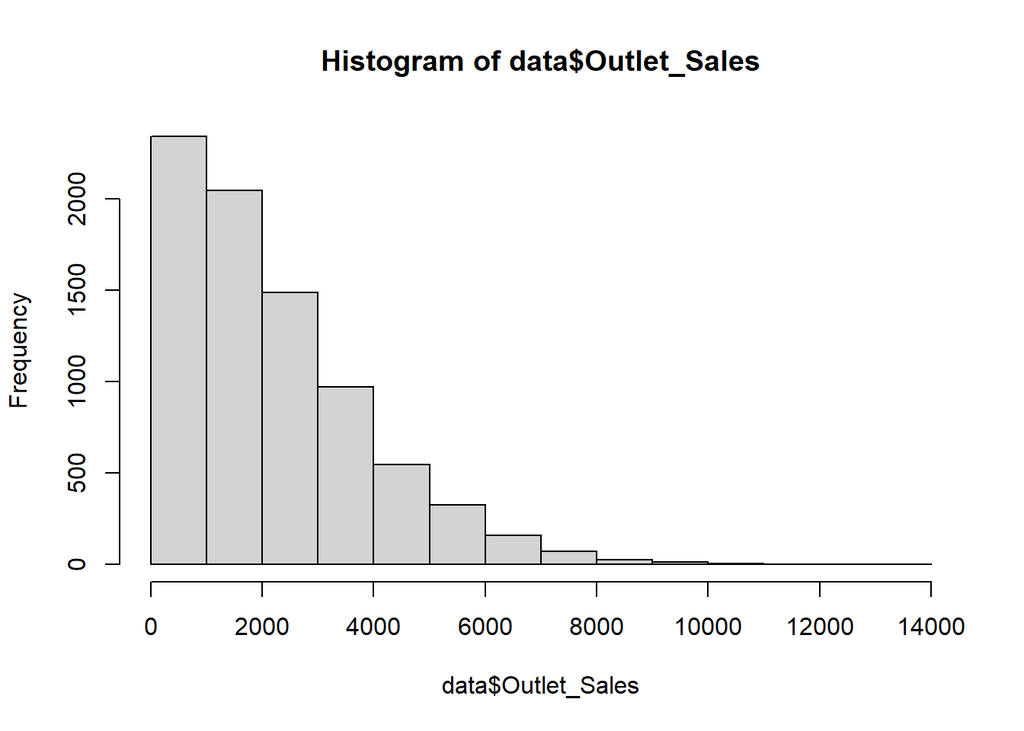

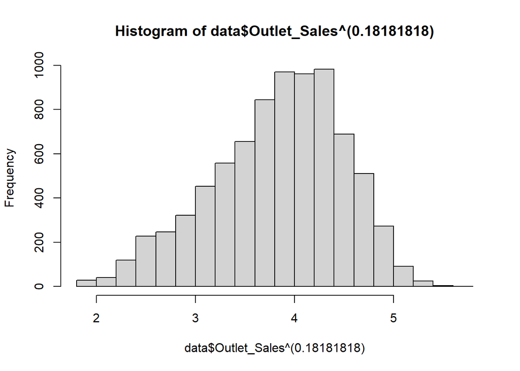

We are going to give the variables *Fat_content*, *Outlet_Location_Type*, and *Outlet_Type* a needed makeover.Rather than keep them as the categorical variables they are, we are going to change all of them to binary indicator variables. This method is not the prettiest code, but it is effective.

```r
#create new columns for fat_content
data$low_fat[data$Fat_Content %in% c("LF","low fat", "Low Fat")] <- 1
data$low_fat[!data$Fat_Content %in% c("LF","low fat", "Low Fat")] <- 0
#new col for reg fat
data$reg_fat[data$Fat_Content %in% c("reg","regular")] <- 1
data$reg_fat[!data$Fat_Content %in% c("reg","regular")] <- 0

#new col for outlet location type
data$Out_Loc_Tier_1[data$Outlet_Location_Type %in% c("Tier 1")] <- 1
data$Out_Loc_Tier_1[!data$Outlet_Location_Type %in% c("Tier 1")] <- 0
data$Out_Loc_Tier_2[data$Outlet_Location_Type %in% c("Tier 2")] <- 1
data$Out_Loc_Tier_2[!data$Outlet_Location_Type %in% c("Tier 2")] <- 0
data$Out_Loc_Tier_3[data$Outlet_Location_Type %in% c("Tier 3")] <- 1
data$Out_Loc_Tier_3[!data$Outlet_Location_Type %in% c("Tier 3")] <- 0

#new col for outlet type
data$Groc_stor[data$Outlet_Type %in% c("Grocery Store")] <- 1
data$Groc_stor[!data$Outlet_Type %in% c("Grocery Store")] <- 0

data$Supermarket1[data$Outlet_Type %in% c("Supermarket Type1")] <- 1
data$Supermarket1[!data$Outlet_Type %in% c("Supermarket Type1")] <- 0

data$Supermarket2[data$Outlet_Type %in% c("Supermarket Type2")] <- 1
data$Supermarket2[!data$Outlet_Type %in% c("Supermarket Type2")] <- 0

data$Supermarket3[data$Outlet_Type %in% c("Supermarket Type3")] <- 1
data$Supermarket3[!data$Outlet_Type %in% c("Supermarket Type3")] <- 0

#remove redundent features, apply to new dataframe
data2 <- subset(data, select = -c(Fat_Content, Type, Outlet_Size,
                                  Outlet_Location_Type, Outlet_Type, Outlet_ID, Item_ID))
```

It is very important to remove those redundent features to prevent overfitting.

The next step is repeating all of these exact transformations to the BLIND dataset. I will omit that from this report, but it is in the raw code if you desire to view it.

### The Model and results

Now for the fun bit. The linear model. While I do prefer more advanced models, I was confident in the results that this linear model returned. These predictors are the result of extensive variable selection.

```r
competitonLM <- lm(Outlet_Sales^(0.18181818)~MRP + Groc_stor + Supermarket3 + Visibility + Out_Loc_Tier_1 +
              Supermarket1 + Out_Loc_Tier_2, data2)
summary(competitonLM)
```

```
##
## Call:
## lm(formula = Outlet_Sales^(0.18181818) ~ MRP + Groc_stor + Supermarket3 +
##     Visibility + Out_Loc_Tier_1 + Supermarket1 + Out_Loc_Tier_2,
##     data = data2)
##
## Residuals:
##      Min       1Q   Median       3Q      Max
## -1.51821 -0.21884  0.03131  0.24876  1.06330
##
## Coefficients:
##                  Estimate Std. Error t value Pr(>|t|)
## (Intercept)     3.032e+00  1.596e-02 189.984  < 2e-16 ***
## MRP             5.642e-03  6.416e-05  87.949  < 2e-16 ***
## Groc_stor      -1.054e+00  1.792e-02 -58.808  < 2e-16 ***
## Supermarket3    5.206e-01  1.715e-02  30.359  < 2e-16 ***
## Visibility     -6.252e-02  8.064e-02  -0.775   0.4382
## Out_Loc_Tier_1  2.071e-02  1.230e-02   1.684   0.0923 .
## Supermarket1    1.085e-01  1.622e-02   6.690 2.39e-11 ***
## Out_Loc_Tier_2  2.197e-02  1.280e-02   1.716   0.0861 .
## ---
## Signif. codes:  0 '***' 0.001 '**' 0.01 '*' 0.05 '.' 0.1 ' ' 1
##
## Residual standard error: 0.3571 on 7985 degrees of freedom
## Multiple R-squared:  0.7052, Adjusted R-squared:  0.7049
## F-statistic:  2728 on 7 and 7985 DF,  p-value: < 2.2e-16
```

```r
competitionResults <- predict(competitonLM, BLIND)

competitionRMSE <- rmse(BLIND$Outlet_Sales,competitionResults^(1/.18181818))
print(competitionRMSE)
```

```
## [1] 1125.428
```

**Results**

This value, 1125.428, is the standard deviation for the errors from the prediction. In this case, 1125 is not bad.